# DDS Case Study 2

Kito Patterson

11/29/2018

# Introduction

DDS Analytics has tasked us with to uncover insights and trends specific to Job Roles within the company and how those factors contribute to turnover/attrition. Ultimately, our goal is to develop a model that will predict churn with a high level of accuracy (Minimum 60%). They have also asked us to shed light on the top 3 variables that have a sizeable impact on attrition rates.

# Primary Objectives

1.) Uncover any intersting trends specific to Job Role  
2.) Report the top 3 factors that contribute to turnover  
3.) Build a model to predict attrition

# Packages

```r
library(ggplot2)
library(corrplot)
library(dplyr)
library(caret)
library(MASS)
library(randomForest)
library(e1071)
```

# Data Import

```r
dfTrain <- read.csv(file="~/Desktop/DDS-CaseStudy2/CaseStudy2-data.csv", header=TRUE, stringsAsFactors=TRUE)

dfVal <- read.csv(file="~/Desktop/DDS-CaseStudy2/CaseStudy2validation.csv", header=TRUE, stringsAsFactors=TRUE)
```

# Data Check

We want to make sure the dataset provided does not have any missing values or mixed data types before we begin our explaoratory and modeling exercises.

```r
#str(df)

#No missing values
#sum(is.na(df))
colSums(is.na(dfTrain))
```

```
##                       ID                      Age                Attrition
##                        0                        0                        0
##           BusinessTravel                DailyRate               Department
##                        0                        0                        0
##         DistanceFromHome                Education           EducationField
##                        0                        0                        0
##            EmployeeCount           EmployeeNumber  EnvironmentSatisfaction
##                        0                        0                        0
##                   Gender               HourlyRate           JobInvolvement
##                        0                        0                        0
##                 JobLevel                  JobRole          JobSatisfaction
##                        0                        0                        0
##            MaritalStatus            MonthlyIncome              MonthlyRate
##                        0                        0                        0
##       NumCompaniesWorked                   Over18                 OverTime
##                        0                        0                        0
##        PercentSalaryHike        PerformanceRating RelationshipSatisfaction
##                        0                        0                        0
##            StandardHours         StockOptionLevel        TotalWorkingYears
##                        0                        0                        0
##    TrainingTimesLastYear          WorkLifeBalance           YearsAtCompany
##                        0                        0                        0
##       YearsInCurrentRole  YearsSinceLastPromotion     YearsWithCurrManager
##                        0                        0                        0
##                     Rand
##                        0
```

```r
#View(summary(df))
```

# Data Preparation

There are a few variables that seem useless for the purposes of this analysis. ID, Standard Hours, Employee Number and Employee Count will be removed from the table

```r
#Recode Attrition Column to numeric if necessary
#df$Attrition2 <- ifelse(df$Attrition == "Yes", 1, 0)

#Drop ID, StandardHours, EmployeeCount, Over18 columns
#Most values do not change so SD is 0
df_stage <- dfTrain[,!(names(dfTrain) %in% c("ID", "StandardHours", "EmployeeNumber", "EmployeeCount", "Over18"))]
```

An additional dataframe was created with only numeric values to be read by a correlation heatmap later in the analysis.

```r
#Return numeric values only
df_numeric <- df_stage[, sapply(df_stage, is.numeric)]

#Correlation Plot
df_corr <- round(cor(df_numeric),2)
```

# Data Exploration

More than 80% of the training dataset consist of employees who are still retained

```r
table(dfTrain$Attrition)
```

```
##
##  No Yes
## 982 188
```

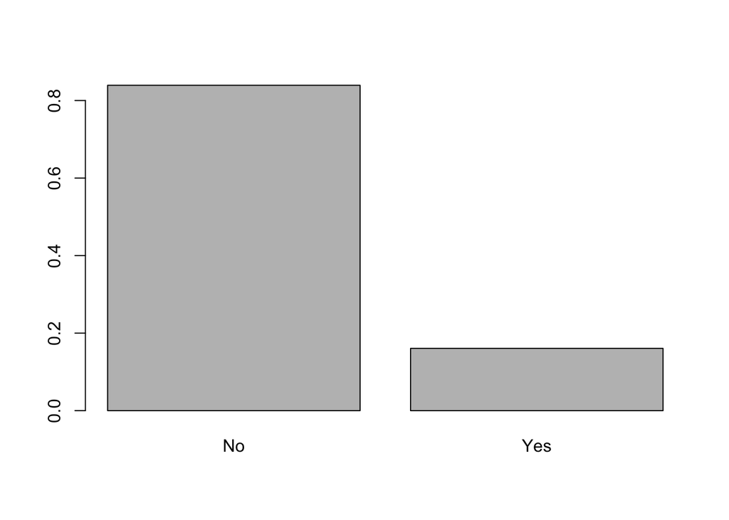

```r
barplot(prop.table(table(dfTrain$Attrition)))
```

We created a correlation matrix to view possible multicollinearity between variables that need to be addressed before the modeling phase to avoid redundancy.

The variables below seem to have high collinearity so we will remove some of them for the Custom model at a later phase:

MonthlyIncome corr JobLevel  
PercentSalaryHike corr PerformanceRating  
TotalWorkingYears corr JobLevel  
Age corr TotalWorkingYears  
YearsInCurrentRole corr TotalWorkingYears

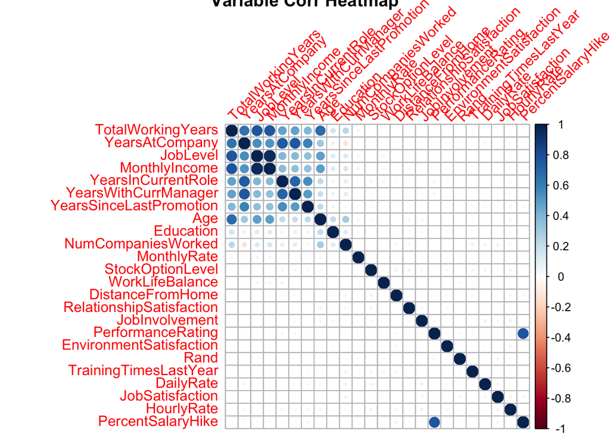

```r
corrplot(df_corr, order="FPC", title="Variable Corr Heatmap",tl.srt=45)
```

Figure A shows the count distribution of employees by job role. Sales Executive jobs are the most prevalent at 22% of all Job Roles followed closely by Research Scientist at 20% and Lab Technicians at 18% rounding out the top 3.

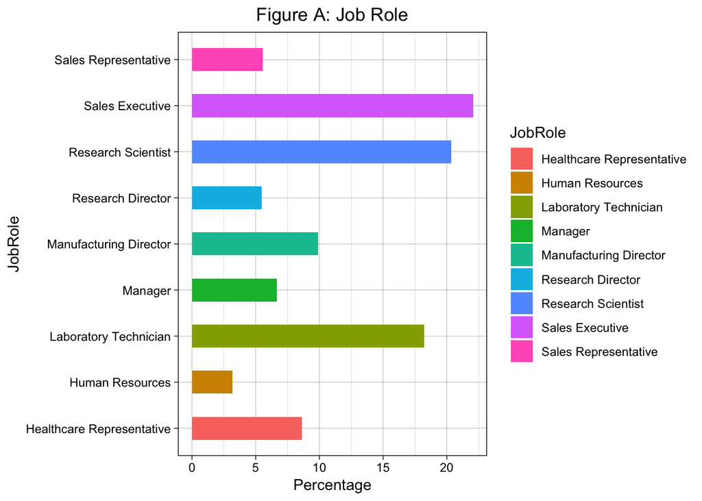

```r
p1 <- ggplot(dfTrain, aes(x=JobRole), color=JobRole) + ggtitle("Figure A: Job Role") +
  geom_bar(aes(y = 100*(..count..)/sum(..count..), fill=JobRole),  width = 0.5) +
  #geom_text(aes(label=100*(..count..)/sum(..count..)), vjust=0) +
  labs(y="Percentage") +
  coord_flip() +
  theme_linedraw() +
  theme(plot.title = element_text(hjust = 0.5))
p1
```

Figure B is another view showing the percentage of total by each Job Role

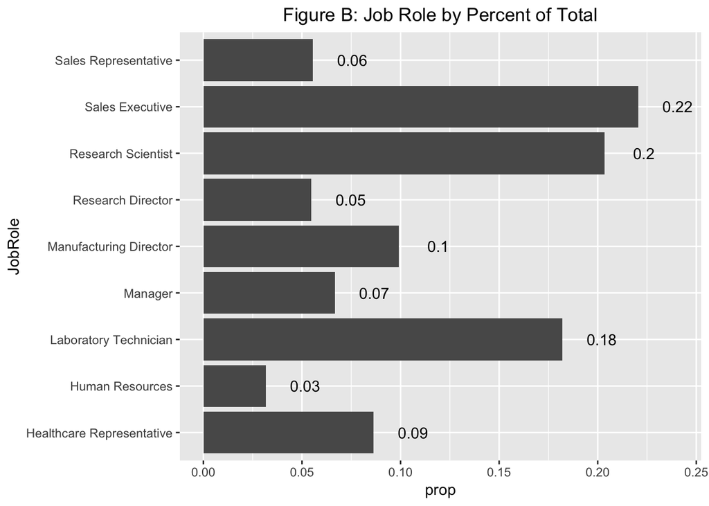

```r
#Test plot above with Percentages
p2 <- ggplot(dfTrain, aes(x=JobRole, y = ..prop.., group=1)) +
  geom_bar() +
  geom_text(stat = "count",
            aes(label = round(..prop.., 2), y = ..prop.. + 0.02)) +
            coord_flip() +
  ggtitle("Figure B: Job Role by Percent of Total") +
  theme(plot.title = element_text(hjust = 0.5))
p2
```

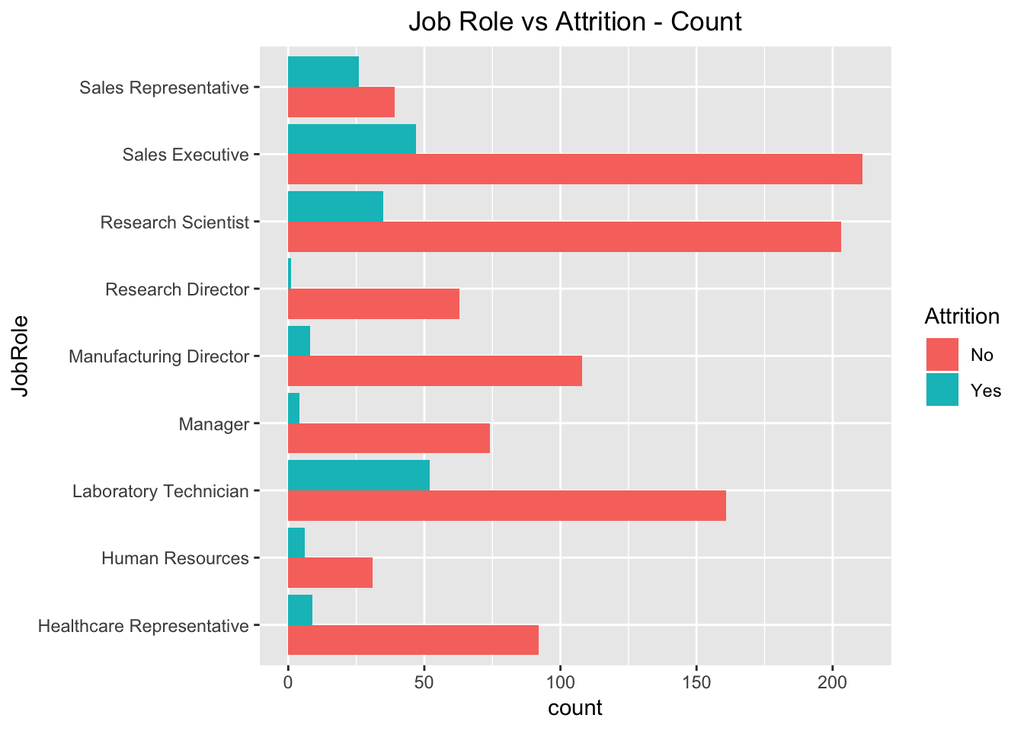

```r
p3 <- ggplot(dfTrain,aes(x = JobRole,fill = Attrition)) +
  geom_bar(position = "dodge") +
    ggtitle("Job Role vs Attrition - Count") +
    coord_flip() +
    theme(plot.title = element_text(hjust = 0.5))
p3
```

Create table for means by JobRole (MAY NOT BE NEEDED). ANOVA table may be a better way to test for difference in means among varying groups.

```r
df_means <- group_by(dfTrain, JobRole) %>%
  summarize(JI_mean = mean(JobInvolvement, na.rm=TRUE),
  PR_mean = mean(PerformanceRating, na.rm=TRUE),
  ES_mean = mean(EnvironmentSatisfaction, na.rm=TRUE))

df_means
```

```
## # A tibble: 9 x 4
##   JobRole                   JI_mean PR_mean ES_mean
##   <fct>                       <dbl>   <dbl>   <dbl>
## 1 Healthcare Representative    2.78    3.14    2.75
## 2 Human Resources              2.76    3.14    2.68
## 3 Laboratory Technician        2.69    3.15    2.77
## 4 Manager                      2.81    3.21    2.79
## 5 Manufacturing Director       2.66    3.21    2.90
## 6 Research Director            2.83    3.09    2.39
## 7 Research Scientist           2.84    3.16    2.66
## 8 Sales Executive              2.70    3.13    2.68
## 9 Sales Representative         2.68    3.15    2.65
```

# Modeling

Logistic Regression Model

```r
lr_mod <- glm(Attrition ~ MonthlyIncome + JobSatisfaction + Age + Education + JobLevel +
  PerformanceRating + YearsSinceLastPromotion + YearsWithCurrManager + WorkLifeBalance +
  YearsAtCompany + JobRole + EducationField , data=df_stage, family=binomial(link='logit'))
```

```r
summary(lr_mod)
```

```
##
## Call:
## glm(formula = Attrition ~ MonthlyIncome + JobSatisfaction + Age +
##     Education + JobLevel + PerformanceRating + YearsSinceLastPromotion +
##     YearsWithCurrManager + WorkLifeBalance + YearsAtCompany +
##     JobRole + EducationField, family = binomial(link = "logit"),
##     data = df_stage)
##
## Deviance Residuals:
##     Min       1Q   Median       3Q      Max
## -1.4372  -0.6259  -0.4457  -0.2377   2.8431
##
## Coefficients:
##                                  Estimate Std. Error z value Pr(>|z|)
## (Intercept)                    -6.577e-01  1.392e+00  -0.473 0.636502
## MonthlyIncome                   1.115e-04  7.536e-05   1.480 0.138925
## JobSatisfaction                -2.592e-01  7.624e-02  -3.400 0.000674 ***
## Age                            -2.643e-02  1.115e-02  -2.371 0.017760 *
## Education                       3.917e-02  8.656e-02   0.453 0.650873
## JobLevel                       -1.972e-01  2.870e-01  -0.687 0.491964
## PerformanceRating               2.221e-01  2.335e-01   0.951 0.341491
## YearsSinceLastPromotion         1.320e-01  3.905e-02   3.379 0.000726 ***
## YearsWithCurrManager           -1.283e-01  4.249e-02  -3.020 0.002525 **
## WorkLifeBalance                -4.305e-01  1.176e-01  -3.662 0.000251 ***
## YearsAtCompany                 -1.810e-02  3.179e-02  -0.569 0.569142
## JobRoleHuman Resources          9.582e-01  6.760e-01   1.417 0.156366
## JobRoleLaboratory Technician    1.341e+00  4.590e-01   2.922 0.003483 **
## JobRoleManager                 -1.127e+00  7.766e-01  -1.451 0.146768
## JobRoleManufacturing Director  -1.552e-01  5.217e-01  -0.298 0.766067
## JobRoleResearch Director       -2.165e+00  1.154e+00  -1.877 0.060561 .
## JobRoleResearch Scientist       6.272e-01  4.690e-01   1.337 0.181133
## JobRoleSales Executive          8.314e-01  4.146e-01   2.005 0.044947 *
## JobRoleSales Representative     1.821e+00  5.183e-01   3.514 0.000442 ***
## EducationFieldLife Sciences     2.860e-01  9.336e-01   0.306 0.759378
## EducationFieldMarketing         4.735e-01  9.715e-01   0.487 0.625961
## EducationFieldMedical           1.771e-01  9.390e-01   0.189 0.850411
## EducationFieldOther            -1.146e-01  1.005e+00  -0.114 0.909160
## EducationFieldTechnical Degree  8.204e-01  9.504e-01   0.863 0.387987
## ---
## Signif. codes:  0 '***' 0.001 '**' 0.01 '*' 0.05 '.' 0.1 ' ' 1
##
## (Dispersion parameter for binomial family taken to be 1)
##
##     Null deviance: 1031.48  on 1169  degrees of freedom
## Residual deviance:  902.24  on 1146  degrees of freedom
## AIC: 950.24
##
## Number of Fisher Scoring iterations: 6
```

Apply training model to test model

```r
#Store the probabilites for every observation in the dataset
dfVal$model_prob <- predict(lr_mod, dfVal, type = "response")
#Tranform the “Yes” and “No” to binary variables
Test <- dfVal  %>% mutate(model_pred = 1*(model_prob > .50) + 0,
                                 visit_binary = 1*(Attrition == "Yes") + 0)
#Compare the newly created columns “model_pred” and “visit_binary” to calculate the accuracy of our model
Test <- Test %>% mutate(accurate = 1*(model_pred == visit_binary))
#Accuracy Score
sum(Test$accurate)/nrow(Test)
```

```
## [1] 0.8466667
```

# Random Forest Model

```r
model1 <- randomForest(Attrition~., data=dfTrain, importance = TRUE)
model1
```

```
##
## Call:
##  randomForest(formula = Attrition ~ ., data = dfTrain, importance = TRUE)
##                Type of random forest: classification
##                      Number of trees: 500
## No. of variables tried at each split: 6
##
##         OOB estimate of  error rate: 14.27%
## Confusion matrix:
##      No Yes class.error
## No  975   7  0.00712831
## Yes 160  28  0.85106383
```

```r
predTrain <- predict(model1, dfVal, type = "class")
```

Checking classification accuracy

```r
confusionMatrix(table(predTrain, dfVal$Attrition))
```

```
## Confusion Matrix and Statistics
##
##
## predTrain  No Yes
##       No  248  42
##       Yes   3   7
##
##                Accuracy : 0.85
##                  95% CI : (0.8045, 0.8884)
##     No Information Rate : 0.8367
##     P-Value [Acc > NIR] : 0.2966
##
##                   Kappa : 0.1926
##  Mcnemar's Test P-Value : 1.473e-08
##
##             Sensitivity : 0.9880
##             Specificity : 0.1429
##          Pos Pred Value : 0.8552
##          Neg Pred Value : 0.7000
##              Prevalence : 0.8367
##          Detection Rate : 0.8267
##    Detection Prevalence : 0.9667
##       Balanced Accuracy : 0.5655
##
##        'Positive' Class : No
##
```

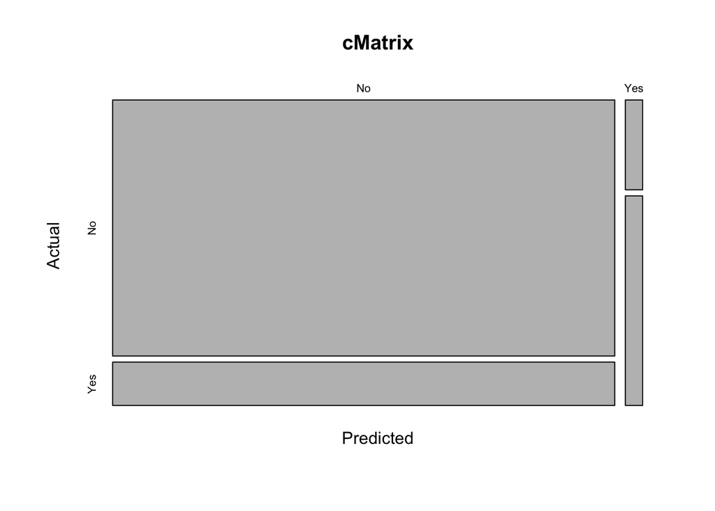

```r
cMatrix<-table(predTrain, dfVal$Attrition)
plot(cMatrix,ylab="Actual", xlab="Predicted", 'Random Forest Confusion Matrix')
```

Check important variables

```r
importance(model1)
```

```
##                                   No         Yes MeanDecreaseAccuracy
## ID                       -0.88533829 -0.60273925          -1.01947963
## Age                       5.17766815  9.60070728           9.18671839
## BusinessTravel            2.07155308  3.22599185           3.37721366
## DailyRate                -0.52962622  1.35565063           0.08408106
## Department                2.74378626  2.55252175           3.91766448
## DistanceFromHome          0.27871786 -0.35362794           0.10823868
## Education                 0.58095084  0.30039513           0.69953861
## EducationField            1.35106843  1.43878490           1.90086865
## EmployeeCount             0.00000000  0.00000000           0.00000000
## EmployeeNumber           -0.46003637 -1.01092094          -0.84018488
## EnvironmentSatisfaction   2.20544905  5.06922176           4.38679316
## Gender                    0.89379209 -0.02693154           0.76342903
## HourlyRate                0.24540379  1.29355580           0.89930744
## JobInvolvement            3.76459531  4.68358874           5.39132667
## JobLevel                  6.56198237  6.24053943           8.72185869
## JobRole                   7.95449630  6.60131020          10.35975613
## JobSatisfaction           3.44533603  2.73882796           4.44798796
## MaritalStatus             6.36676952  6.45952886           8.65615621
## MonthlyIncome             9.58801869  4.80420419          11.50462663
## MonthlyRate               1.08835617 -2.87846737          -0.23032021
## NumCompaniesWorked        3.62712526  4.68134220           5.15962935
## Over18                    0.00000000  0.00000000           0.00000000
## OverTime                 12.38340212 16.84174232          18.10278230
## PercentSalaryHike         0.68928446 -1.27943634          -0.02066786
## PerformanceRating         0.17545421  0.91198050           0.56019242
## RelationshipSatisfaction  1.78289927  2.36868065           2.54104281
## StandardHours             0.00000000  0.00000000           0.00000000
## StockOptionLevel          7.55156305  8.72115337          10.57633687
## TotalWorkingYears         6.35181541  6.39820071           9.02133583
## TrainingTimesLastYear     0.01528007 -0.52658845          -0.21210919
## WorkLifeBalance           3.06502211  5.58797313           5.46383133
## YearsAtCompany            6.23712633  4.15047353           7.63344365
## YearsInCurrentRole        4.56092119  4.90796382           6.75502342
## YearsSinceLastPromotion   1.94309717  2.63406545           2.92674287
## YearsWithCurrManager      5.36857073  5.64808334           7.39044272
## Rand                     -0.52436306 -0.25086297          -0.58957554
##                          MeanDecreaseGini
## ID                              13.968307
## Age                             17.061294
```

[output cut: 19 more lines]

```
## Over18                           0.000000
## OverTime                        14.380986
## PercentSalaryHike                9.563196
## PerformanceRating                1.302828
## RelationshipSatisfaction         5.691535
## StandardHours                    0.000000
## StockOptionLevel                 8.927541
## TotalWorkingYears               14.399520
## TrainingTimesLastYear            6.193951
## WorkLifeBalance                  8.081328
## YearsAtCompany                  11.813316
## YearsInCurrentRole               6.919174
## YearsSinceLastPromotion          8.045332
## YearsWithCurrManager             8.217917
## Rand                            14.001398
```